# HW03-P2 Adv Map Viz

**Important GitHub Note**

DO NOT add, commit, and push anything in the `data/raw` folder. The files for this are too big, and you’ll run into file size restrictions. You can ignore them as follows:

- Open GitHub Desktop
- Right-click any file inside `data/raw` –> select `Ignore folder (add to .gitignore)` –> select `data/raw`

## Introduction

The US Walkability Index dataset provides relative walkability information for all 2019 census block groups. Through these exercises, we will explore walkability patterns across the United States.

**Requirements:**

- Downloaded data and read it in
- MN plot of walkability (filtering + choropleth)
- save filtered dataset as R Data file
- Get US county boundaries, transform to have same CRS if necessary
- Spatial join (order matters), Weighted mean and SD by county
- County-level map of Average Walkability of a state of choice
- County-level map of SD in Walkability of a state of choice
- Scatterplot of SD and Average Walkability overall
- Scatterplot of SD and Average Walkability faceted by state
- Insight sentences about graphic

## 1 Donwload & Read Data

Go to [data.gov](https://catalog.data.gov/dataset/), search for “walkability index”, and download the US Walkability Index dataset (the Zip file called `WalkabilityIndex.zip`). Unzip this file within the `data/raw` folder of this homework.

Read in the dataset with `st_read()` by providing a relative path to the `WalkabilityIndex/Natl_WI.gdb` folder (as opposed to a file within that folder). This will take a few seconds. You should see a message `using driver OpenFileGDB` during this process.

```r
library(sf)
library(dplyr)
library(ggplot2)

walk_index <- st_read("p2data/Natl_WI.gdb")
```

## 2 MN Walkability

Let’s first get a sense for the data by making a map of walkability indices for Minnesota. You will first need to filter the `walk_index` dataset by using the `STATEFP` variable. `STATEFP` contains the state’s [FIPS code](https://transition.fcc.gov/oet/info/maps/census/fips/fips.txt) which is `"27"` for Minnesota. The `NatWalkInd` variable contains the walkability indices. Save this smaller dataset in a `data/processed` folder as `walk_index_mn.RData`, which is an R Data file.

```r
walk_index_mn <- walk_index |>
  filter(STATEFP == "27")

save(walk_index_mn, file = 'p2data/processed/walk_index_mn.RData')
```

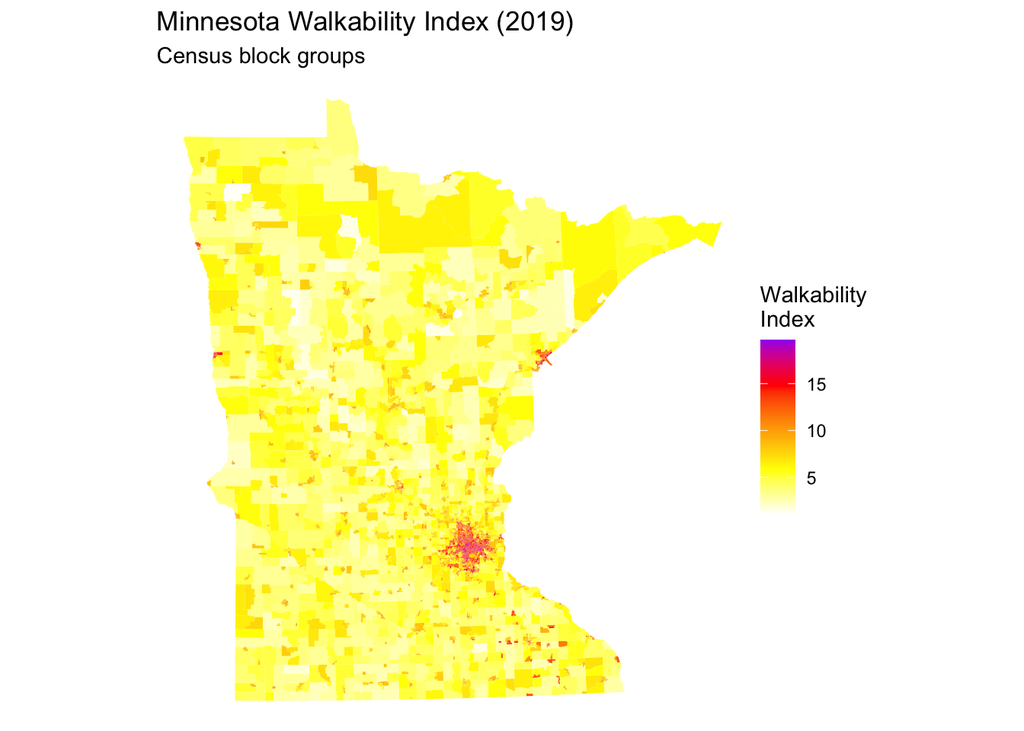

```r
load('p2data/processed/walk_index_mn.RData')

ggplot(walk_index_mn) +
  geom_sf(aes(fill = NatWalkInd), color = NA) +
  scale_fill_gradientn(
    colors = c("white", "yellow", "orange", "red", "purple"),
    name = "Walkability\nIndex") +
  labs(
    title = "Minnesota Walkability Index (2019)",
    subtitle = "Census block groups") +
  theme_void()
```

## 3 US County Boundaries

We will start setting up to do a nationwide exploration of walkability. Use the `us_counties()` function within the `USAboundaries` package to obtain the most current low resolution county boundaries for all US counties. (Look up the documentation for this function to see how to structure the arguments.)

If needed, transform `all_us_counties` to have the same CRS as the Walkability Index dataset.

```r
library(USAboundaries)
all_us_counties <- us_counties(resolution = "low")

all_us_counties <- st_transform(all_us_counties, st_crs(walk_index))

sf::st_crs(all_us_counties)
```

```
Coordinate Reference System:
  User input: USA_Contiguous_Albers_Equal_Area_Conic_USGS_version
  wkt:
PROJCRS["USA_Contiguous_Albers_Equal_Area_Conic_USGS_version",
    BASEGEOGCRS["NAD83",
        DATUM["North American Datum 1983",
            ELLIPSOID["GRS 1980",6378137,298.257222101,
                LENGTHUNIT["metre",1]]],
        PRIMEM["Greenwich",0,
            ANGLEUNIT["degree",0.0174532925199433]],
        ID["EPSG",4269]],
    CONVERSION["USA_Contiguous_Albers_Equal_Area_Conic_USGS_version",
        METHOD["Albers Equal Area",
            ID["EPSG",9822]],
        PARAMETER["Latitude of false origin",23,
            ANGLEUNIT["degree",0.0174532925199433],
            ID["EPSG",8821]],
        PARAMETER["Longitude of false origin",-96,
            ANGLEUNIT["degree",0.0174532925199433],
            ID["EPSG",8822]],
        PARAMETER["Latitude of 1st standard parallel",29.5,
            ANGLEUNIT["degree",0.0174532925199433],
            ID["EPSG",8823]],
        PARAMETER["Latitude of 2nd standard parallel",45.5,
            ANGLEUNIT["degree",0.0174532925199433],
            ID["EPSG",8824]],
        PARAMETER["Easting at false origin",0,
            LENGTHUNIT["metre",1],
            ID["EPSG",8826]],
        PARAMETER["Northing at false origin",0,
            LENGTHUNIT["metre",1],
            ID["EPSG",8827]]],
    CS[Cartesian,2],
        AXIS["(E)",east,
            ORDER[1],
            LENGTHUNIT["metre",1]],
        AXIS["(N)",north,
            ORDER[2],
            LENGTHUNIT["metre",1]],
    USAGE[
        SCOPE["Not known."],
        AREA["United States (USA) - CONUS onshore - Alabama; Arizona; Arkansas; California; Colorado; Connecticut; Delaware; Florida; Georgia; Idaho; Illinois; Indiana; Iowa; Kansas; Kentucky; Louisiana; Maine; Maryland; Massachusetts; Michigan; Minnesota; Mississippi; Missouri; Montana; Nebraska; N…
        BBOX[24.41,-124.79,49.38,-66.91]],
    ID["ESRI",102039]]
```

```r
sf::st_crs(walk_index)
```

```
Coordinate Reference System:
  User input: USA_Contiguous_Albers_Equal_Area_Conic_USGS_version
  wkt:
PROJCRS["USA_Contiguous_Albers_Equal_Area_Conic_USGS_version",
    BASEGEOGCRS["NAD83",
        DATUM["North American Datum 1983",
            ELLIPSOID["GRS 1980",6378137,298.257222101,
                LENGTHUNIT["metre",1]]],
        PRIMEM["Greenwich",0,
            ANGLEUNIT["degree",0.0174532925199433]],
        ID["EPSG",4269]],
    CONVERSION["USA_Contiguous_Albers_Equal_Area_Conic_USGS_version",
        METHOD["Albers Equal Area",
            ID["EPSG",9822]],
        PARAMETER["Latitude of false origin",23,
            ANGLEUNIT["degree",0.0174532925199433],
            ID["EPSG",8821]],
        PARAMETER["Longitude of false origin",-96,
            ANGLEUNIT["degree",0.0174532925199433],
            ID["EPSG",8822]],
        PARAMETER["Latitude of 1st standard parallel",29.5,
            ANGLEUNIT["degree",0.0174532925199433],
            ID["EPSG",8823]],
        PARAMETER["Latitude of 2nd standard parallel",45.5,
            ANGLEUNIT["degree",0.0174532925199433],
            ID["EPSG",8824]],
        PARAMETER["Easting at false origin",0,
            LENGTHUNIT["metre",1],
            ID["EPSG",8826]],
        PARAMETER["Northing at false origin",0,
            LENGTHUNIT["metre",1],
            ID["EPSG",8827]]],
    CS[Cartesian,2],
        AXIS["(E)",east,
            ORDER[1],
            LENGTHUNIT["metre",1]],
        AXIS["(N)",north,
            ORDER[2],
            LENGTHUNIT["metre",1]],
    USAGE[
        SCOPE["Not known."],
        AREA["United States (USA) - CONUS onshore - Alabama; Arizona; Arkansas; California; Colorado; Connecticut; Delaware; Florida; Georgia; Idaho; Illinois; Indiana; Iowa; Kansas; Kentucky; Louisiana; Maine; Maryland; Massachusetts; Michigan; Minnesota; Mississippi; Missouri; Montana; Nebraska; N…
        BBOX[24.41,-124.79,49.38,-66.91]],
    ID["ESRI",102039]]
```

## 4 Join Walkability & Boundaries

Use `st_join()` within the `sf` package to insert walkability information into the `all_us_counties` dataset. Because the walkability information is available over regions that are smaller than counties, this join will merge in multiple regions of walkability information for each county.

After the join, summarize the walkability index within each county with the weighted mean and weighted standard deviation, where the weights are given by the `Shape_Area` variable.

*Background information about weighted summary measures:* In an ordinary (unweighted) mean and standard deviation, each observation gets a weight of 1–that is, every observation contributes equally to the calculation. We want to compute a weighted measure because the regions within a county have different areas.

*Techinical implementation:* You can install the `Hmisc` package and use the following:

- `Hmisc::wtd.mean(x, weights)`
- `Hmisc::wtd.var(x, weights)`
  - This computes a weighted variance–you’ll need to take the square root after this.

Note: DON’T add `library(Hmisc)` to your package loading code chunk. `Hmisc` contains a function called `summarize()` that will conflict with `dplyr::summarize()`.

In both functions, `x` represents the vector of numerical entries you want to summarize, and `weights` is a vector of the same length as `x` that gives the weight for each entry of `x`.

```r
# Use st_join to merge county boundaries and regions where we have walkability index data
all_us_counties_walk_index <- st_join(all_us_counties, walk_index)

# Use Hmisc::wtd.mean() and Hmisc::wtd.var() to compute the weighted mean and SD of the walkability index (weighted by Shape_Area)
all_us_counties_walk_index_summ <- all_us_counties_walk_index |>
  group_by(geoid) |>
  summarize(
    wi_mean = Hmisc::wtd.mean(NatWalkInd, weights = Shape_Area, na.rm = TRUE),
    wi_sd   = sqrt(Hmisc::wtd.var(NatWalkInd, weights = Shape_Area, na.rm = TRUE)))
```

## 5 County Average Walkability

Pick one state. For this state, make a map that allows you to see average walkability within a county and a map that allows you to see the variability in walkability across a county. (The goal of this part is to get a sense of the county-level walkability data before zooming out to do a nationwide exploration.)

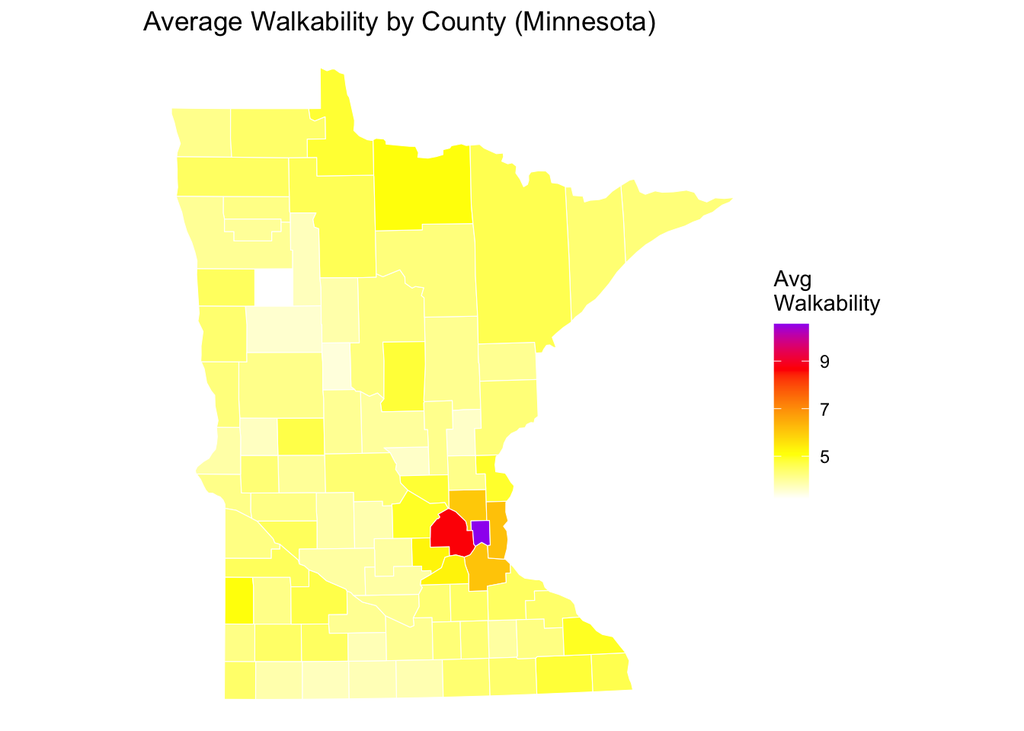

```r
# Filter down to one state and make maps
one_state <- all_us_counties_walk_index_summ |>
  mutate(statefp = substr(geoid, 1, 2)) |>
  filter(statefp == "27")


ggplot(one_state) +
  geom_sf(aes(fill = wi_mean), color = "white") +
  scale_fill_gradientn(
    colors = c("white", "yellow", "orange", "red", "purple"),
    name = "Avg\nWalkability") +
  labs(title = "Average Walkability by County (Minnesota)") +
  theme_void()
```

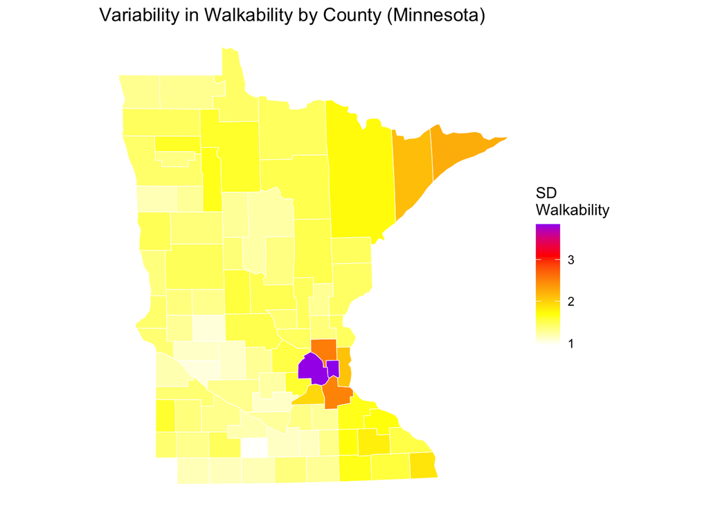

```r
ggplot(one_state) +
  geom_sf(aes(fill = wi_sd), color = "white") +
  scale_fill_gradientn(
    colors = c("white", "yellow", "orange", "red", "purple"),
    name = "SD\nWalkability",
    na.value = "grey"
  ) +
  labs(title = "Variability in Walkability by County (Minnesota)") +
  theme_void()
```

## 6 Walkability Variability vs Average

Make plots (not maps) that allow you to explore if there is a relationship between the variability in walkability in a county and the average level of walkability in a county. One plot should depict the United States as a whole, and a second plot should break down this relationship across states. Summarize your findings and what you would be curious to explore next based on your explorations.

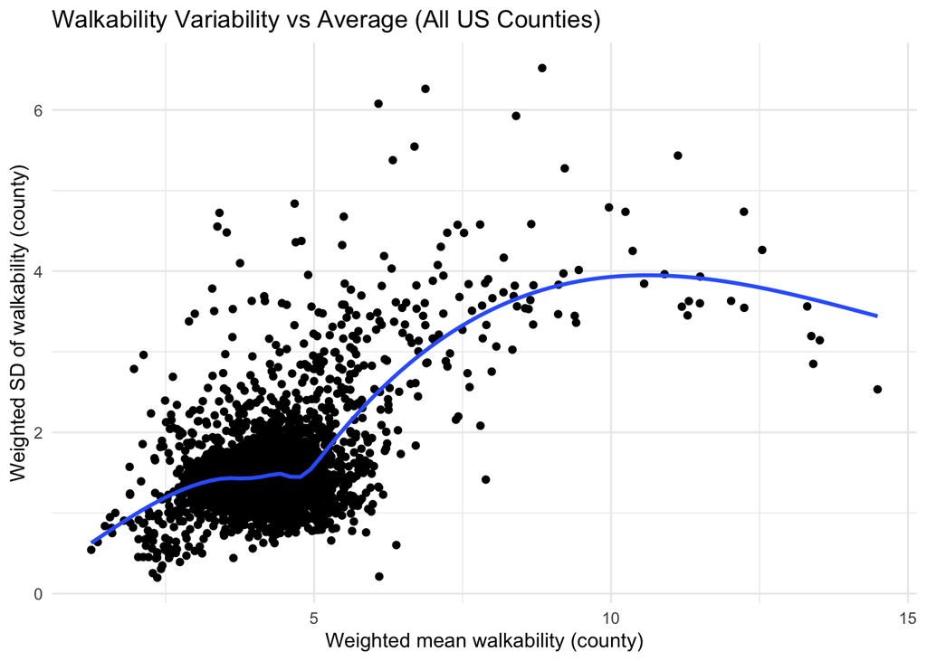

```r
county_wi <- all_us_counties_walk_index_summ |>
  st_drop_geometry() |>
  mutate(statefp = substr(geoid, 1, 2))

ggplot(county_wi, aes(x = wi_mean, y = wi_sd)) +
  geom_point() +
  geom_smooth(se = FALSE) +
  labs(
    title = "Walkability Variability vs Average (All US Counties)",
    x = "Weighted mean walkability (county)",
    y = "Weighted SD of walkability (county)") +
  theme_minimal()
```

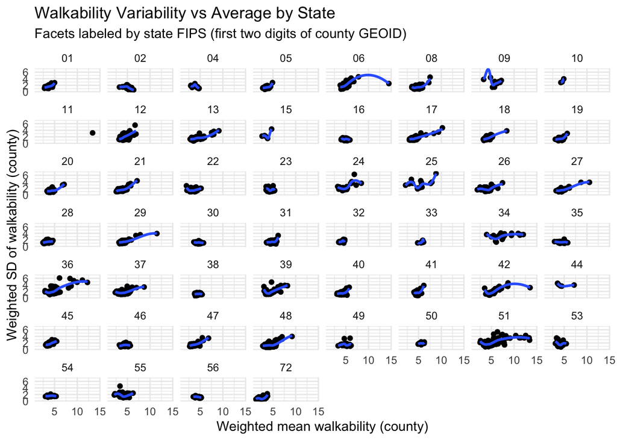

```r
ggplot(county_wi, aes(x = wi_mean, y = wi_sd)) +
  geom_point() +
  geom_smooth(se = FALSE) +
  facet_wrap(~ statefp) +
  labs(
    title = "Walkability Variability vs Average by State",
    subtitle = "Facets labeled by state FIPS (first two digits of county GEOID)",
    x = "Weighted mean walkability (county)",
    y = "Weighted SD of walkability (county)") +
  theme_minimal()
```

> Summarize your findings and what you would be curious to explore next based on your explorations.

plot 1: Across US counties, higher average walkability is generally associated with higher variability, this could potentially be counties with walkable urban cores that also include less-walkable suburban/rural areas. The relationship flattens at the highest averages, where counties may be more equally walkable.

plot 2: The mean–variability relationship appears in many states, but the strength/shape differs, which makes me curious how county size, urbanization, or population density affects both the average and SD so I’m going to make a new data point for population density and explore the relationships between population density(pop_density) and average walkability and sd of walkability.

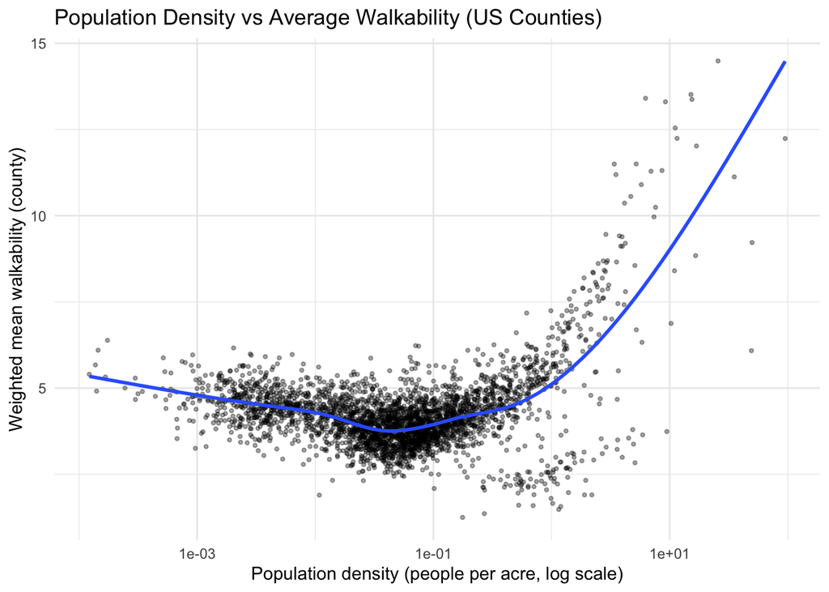

```r
county_density_simple <- all_us_counties_walk_index |>
  group_by(geoid) |>
  summarize(
    pop_total  = sum(TotPop),
    land_acres = sum(Ac_Land)) |>
  mutate(pop_density = pop_total / land_acres)

county_wi_density <- all_us_counties_walk_index_summ |>
  st_drop_geometry() |>
  left_join(county_density_simple |> select(geoid, pop_density), by = "geoid")


ggplot(county_wi_density, aes(x = pop_density, y = wi_mean)) +
  geom_point(alpha = 0.35, size = 0.8) +
  geom_smooth(se = FALSE) +
  scale_x_log10() +
  labs(
    title = "Population Density vs Average Walkability (US Counties)",
    x = "Population density (people per acre, log scale)",
    y = "Weighted mean walkability (county)") +
  theme_minimal()
```

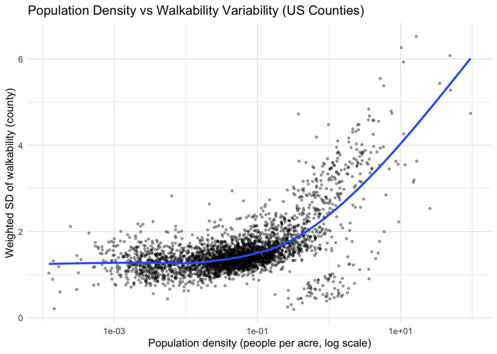

```r
ggplot(county_wi_density, aes(x = pop_density, y = wi_sd)) +
  geom_point(alpha = 0.35, size = 0.8) +
  geom_smooth(se = FALSE) +
  scale_x_log10() +
  labs(
    title = "Population Density vs Walkability Variability (US Counties)",
    x = "Population density (people per acre, log scale)",
    y = "Weighted SD of walkability (county)") +
  theme_minimal()
```

Population density has a very strong relationship with both average walkability and SD of walkability, which makes sense. Denser/more urban areas have much more sidewalks and destinations to walk to so it makes sense that the average walkability increases. At the same time, these urban areas also usually don’t occupy a whole county area, so as density rises the within county differences often increases, leading to a higher SD.

## Resources Reflection (required)

List the resources you used to help with this assignment then write 3-5 sentence reflection on which resources were most helpful in finishing this task.

**Resources:**

- previous activities
- google search

**Reflection:** A lot of this was similar ideas to part 1 of this homework so I built off of those ideas/strategies. I had to look up documentation for switching to log scale for the last 2 plots since the range of population density and there were extreme values that were stretching the x axis a little bit too much.